# Prostate Capsular Involvement Prediction

A Modern Extension of a 2018 Analysis

Author

Navid Hedayati

Published

August 2026

**Warning**

This project is intended for statistical education and methodological demonstration. It is not a medical device and must not be used to make clinical decisions.

## Abstract

**Background:** A 2018 SDSU analysis used logistic regression to examine baseline measurements associated with prostatic capsule penetration. This project reproduced that work and extended it using prespecified methods focused on out-of-sample prediction, calibration, and model stability.

**Objective:** To evaluate how accurately baseline clinical measurements predict prostatic capsule penetration among patients diagnosed with prostate cancer and whether limited modern extensions improve predictive performance.

**Methods:** The public Prostate Cancer Study dataset contained 380 observations and 153 outcomes. The historical reproduction used 377 complete cases. Three logistic regression models were compared using stratified 10-fold cross-validation repeated 20 times: the historical benchmark, a primary model containing age, categorical digital rectal examination findings, `log2(psa)`, and Gleason score, and a nonlinear PSA model. Performance measures included ROC AUC, Brier score, log loss, calibration intercept, calibration slope, and prediction stability. Sensitivity analyses evaluated `dcaps` and two zero Gleason scores; tumor volume was exploratory.

**Results:** The principal historical coefficients, confidence intervals, odds ratios, and AIC were reproduced. One p-value was corrected from 0.31 to 0.02997, and the documented stepwise procedure selected a different model from the one ultimately reported. Mean cross-validated AUC was 0.809 for the historical benchmark, 0.810 for the primary model, and 0.805 for the nonlinear model. The historical and primary models had nearly identical prediction error. Calibration slopes were 0.920, 0.914, and 0.884, respectively, indicating modest overfitting that was greatest for the nonlinear model. Adding `dcaps` and excluding the zero Gleason scores did not materially change performance. Tumor-volume findings were inconclusive.

**Conclusions:** The historical results were highly reproducible, and the original predictors retained useful but imperfect discrimination. Additional complexity did not provide a clear or stable predictive benefit. The findings favor a parsimonious logistic regression model but represent internal validation of a small historical teaching dataset, not a contemporary clinical prediction tool.

# 1 Introduction

## 1.1 Prostatic capsule penetration

Prostatic capsule penetration indicates that a prostate tumor has extended through the boundary of the prostate rather than remaining confined within it. In this project, capsule penetration is represented as a binary outcome: penetration was either observed or not observed.

Estimating the probability of capsule penetration from baseline clinical measurements is a prediction problem. Potential predictors in the available data include age, prostate-specific antigen (PSA), Gleason score, and findings from a digital rectal examination.

The study population consists entirely of patients already diagnosed with prostate cancer. Accordingly, this project does not examine cancer screening or initial prostate cancer diagnosis. It evaluates whether baseline measurements can distinguish patients with and without capsule penetration within this historical clinical population.

The dataset is relatively small, historical, and derived from a single clinical setting. The objective is therefore methodological and educational. The analysis is not intended to produce a contemporary clinical prediction tool.

## 1.2 Historical project

The project originated in a 2018 analysis completed for STAT 696: Statistical Communication in Data Science at San Diego State University. That analysis examined the Prostate Cancer Study dataset using descriptive statistics, univariate comparisons, and logistic regression.

Although the original report was titled *Detection of Prostate Cancer: Data Analysis Report 2*, its modeled outcome was penetration of the prostatic capsule among patients with prostate cancer. The present project uses outcome terminology that more precisely reflects the analysis.

The final logistic regression model reported in 2018 was:

```r
capsule ~ factor(dpros) + psa + gleason
```

The model included digital rectal examination findings (`dpros`), PSA, and Gleason score. The historical report concluded that these measurements were associated with capsule penetration, while age and recorded race were not.

The 2018 work provides the foundation for the present project. It is retained as a historical analysis rather than rewritten according to current practices. The first objective of the extension was to determine whether the earlier numerical results could be recovered from the verified historical dataset and documented R workflow.

## 1.3 Motivation for a modern extension

The 2018 analysis was appropriate to its course context, but it primarily evaluated in-sample statistical associations. It did not estimate how well the fitted model would predict outcomes for observations that were not used to estimate its coefficients.

Several methodological questions therefore remained:

- Could the reported historical results be reproduced exactly?
- Did the documented model-selection procedure lead directly to the reported final model?
- How well would the historical model discriminate between outcomes in held-out observations?
- Were its predicted probabilities well calibrated?
- Would a modern representation of PSA improve prediction?
- Would additional model flexibility improve performance or primarily increase instability?
- Would including `dcaps` or tumor volume add useful predictive information?

The modern extension addresses these questions through a prespecified and reproducible workflow. The analysis separates historical reproduction from modern model evaluation, uses repeated cross-validation rather than apparent full-data performance as its primary assessment, evaluates both discrimination and calibration, and records the stability of performance and individual predictions across resamples.

The extension is deliberately limited in scope. It does not conduct an unrestricted search across algorithms, transformations, interactions, or predictor combinations. The small sample size favors a focused comparison of interpretable models whose roles were established before their performance was examined.

This approach treats the historical work as a scientific starting point. The goal is not to judge the earlier analysis by standards that were outside its original purpose, but to demonstrate how reproducibility, prespecification, and internal validation can extend an existing statistical project.

## 1.4 Research questions and objectives

The central research question is:

> How accurately can baseline clinical measurements predict prostatic capsule penetration among patients diagnosed with prostate cancer?

Two secondary questions are considered:

1. How does including baseline detection of capsular involvement (`dcaps`) affect predictive performance?
2. Does ultrasound-derived tumor volume (`vol`) provide additional predictive information?

The `dcaps` analysis is prespecified as a sensitivity analysis because this measurement directly records whether possible capsular involvement was detected during the baseline rectal examination.

Tumor volume is treated as exploratory because it was available in the canonical public dataset but was not included in the SDSU dataset used in 2018. Its interpretation is also complicated by the large number of recorded zero values.

The project has the following objectives:

1. reproduce and verify the principal numerical results of the 2018 analysis;
2. identify and classify discrepancies between the historical report and reproduced workflow;
3. develop a documented and reproducible R analysis;
4. estimate out-of-sample predictive performance through repeated cross-validation;
5. evaluate discrimination, calibration, overall prediction error, and model stability;
6. compare the historical model with a prespecified primary modern model;
7. determine whether limited nonlinear modeling of PSA improves prediction;
8. evaluate the effect of adding `dcaps`;
9. assess sensitivity to the two recorded zero Gleason scores; and
10. explore whether tumor volume adds stable predictive information.

# 2 Data

## 2.1 Source and provenance

The project uses the Prostate Cancer Study dataset described by Hosmer and Lemeshow in *Applied Logistic Regression*. The data were collected by Dr. Donn Young at The Ohio State University Comprehensive Cancer Center.

The published values were modified to protect patient confidentiality. Consequently, the records should be understood as a historical teaching dataset rather than an unmodified collection of contemporary patient measurements.

The canonical public version is distributed as the `PCS` dataset in the R package `lbreg`. It contains 380 observations and nine variables.

The dataset used in the 2018 SDSU project contained eight variables. A direct comparison established that it is an exact subset of the canonical public dataset after:

1. renaming the public outcome variable `tumor` to `capsule`; and
2. excluding ultrasound-derived tumor volume (`vol`).

All remaining values, observation order, outcome values, and missing-value locations matched exactly.

The modern project acquires the data reproducibly from `lbreg::PCS`. The acquisition script verifies the expected dimensions, variable names, identifiers, outcome counts, missing-value locations, and transformations before saving the processed analysis files. Generated datasets are excluded from version control and can be recreated from the documented public source.

## 2.2 Outcome and predictors

The outcome is prostatic capsule penetration:

- `capsule = 0`: no capsule penetration;
- `capsule = 1`: capsule penetration.

The predicted quantity in the modern analysis is the probability that `capsule = 1`.

The variables and their analytical roles are summarized in Table 1.

Table 1: Dataset variables and analytical roles

| Variable | Meaning | Analytical role |
| --- | --- | --- |
| `id` | Record identification code | Used only to preserve and verify observation identity; never used as a predictor |
| `capsule` | Prostatic capsule penetration | Binary outcome |
| `age` | Age in years | Primary modern predictor |
| `race` | Historical two-category race code | Historical and descriptive analyses only |
| `dpros` | Four-level digital rectal examination result | Historical and primary modern predictor |
| `dcaps` | Detection of capsular involvement during rectal examination | Prespecified sensitivity predictor |
| `psa` | Prostate-specific antigen | Historical and primary modern predictor |
| `vol` | Tumor volume obtained by ultrasound | Secondary exploratory predictor |
| `gleason` | Total Gleason score | Historical and primary modern predictor |

In the historical benchmark, PSA is modeled in its original units. In the primary modern model, PSA is represented as `log2(psa)`, allowing its coefficient to be interpreted as the change associated with a doubling of PSA.

`dpros` is modeled as a categorical predictor because its four levels should not be assumed to be equally spaced. Age and Gleason score are modeled as continuous terms in the primary analysis.

Race is not included in the modern predictive models. Its historical coding contains only two categories, only 36 observations are assigned to the second category, and three values are missing. In addition, the confidentiality-modified data do not support a meaningful contemporary interpretation of race or an adequate assessment of model fairness.

## 2.3 Analysis populations

The project uses related but distinct analysis populations, summarized in Table 2.

Table 2: Analysis populations

| Analysis stage | Observations | Capsule-penetration outcomes | Purpose |
| --- | --- | --- | --- |
| Canonical acquired dataset | 380 | 153 | Verified public source and modern data |
| Historical reproduction | 377 | 151 | Reproduce the 2018 complete-case workflow |
| Primary modern analysis | 380 | 153 | Main repeated cross-validation analysis |
| `dcaps` sensitivity analysis | 380 | 153 | Evaluate incremental predictive information from `dcaps` |
| Zero-Gleason sensitivity analysis | 378 | 153 | Assess the influence of records 282 and 357 |
| Tumor-volume exploratory analysis | 380 | 153 | Explore the two-part volume representation |

The historical reproduction excludes records 22, 46, and 252 because race is missing. This complete-case deletion is preserved for historical comparability even though race is not present in the reported final historical model.

The primary modern predictors contain no missing values, so all 380 observations are retained without imputation.

The zero-Gleason sensitivity analysis excludes records 282 and 357. Both records have `capsule = 0`, so this reduced population contains 153 outcomes among 378 observations.

## 2.4 Data limitations

Several characteristics of the dataset affect interpretation.

First, race is missing for records 22, 46, and 252. The historical analysis removed these observations through complete-case deletion, while the modern analysis retains them because race is not a modern predictor.

Second, records 282 and 357 have Gleason score equal to zero. The public documentation permits values from 0 through 10, but zero is unusual. The primary analysis retains these values as documented, while a prespecified sensitivity analysis evaluates the effect of excluding them.

Third, 167 observations have tumor volume equal to zero. The available documentation does not establish whether zero consistently represents no measurable volume, a measurement below detection, an examination not performed, or another historical coding practice. Tumor volume is therefore represented using separate zero-versus-positive and positive-volume terms, and the results are treated as exploratory.

Fourth, the dataset was obtained from a single historical clinical setting and contains only 380 observations. The values were modified to preserve confidentiality, and the available demographic information is limited.

These features restrict the precision, generalizability, fairness assessment, and contemporary clinical relevance of the analysis. The dataset remains valuable for studying statistical reproducibility and prediction methodology, but it cannot support clinical deployment of a prediction model.

# 3 Historical Reproduction

## 3.1 Reproduction approach

The historical reproduction evaluated whether the principal numerical results and conclusions of the 2018 SDSU project could be recovered from the verified historical dataset and documented R workflow. Its purpose was to reproduce the earlier analysis faithfully, rather than to revise it according to current statistical practice.

The reproduction used the eight-variable SDSU version of the dataset. Following the original workflow, complete-case deletion was applied across all variables. Records 22, 46, and 252 were excluded because race was missing, leaving 377 observations, including 151 capsule-penetration outcomes.

The workflow reproduced:

- dataset and outcome counts;
- descriptive statistics and exploratory figures;
- two-sample and chi-square tests;
- the documented stepwise model-selection procedure;
- the final logistic regression model reported in 2018;
- coefficient estimates, confidence intervals, odds ratios, and AIC; and
- residual, leverage, and influence diagnostics.

Numerical results were classified as reproduced, affected only by rounding, corrected, not reproducible, or ambiguous according to criteria established before running the reproduction. The complete technical protocol is provided in the historical reproduction plan.

## 3.2 Reproduced results

The dataset description and principal descriptive results were reproduced successfully. The historical analysis population had mean age 66.04 years, mean PSA 15.41, and mean Gleason score 6.38.

The univariate analyses also recovered the main findings of the 2018 report. PSA and Gleason score differed substantially between patients with and without capsule penetration, whereas age did not show evidence of a difference. Digital rectal examination findings (`dpros`) and baseline detection of capsular involvement (`dcaps`) were associated with capsule-penetration status. Recorded race was not associated with the outcome.

These comparisons represent unadjusted associations. They do not measure out-of-sample prediction and should not be interpreted as evidence of causal effects.

The final logistic regression model reported in 2018 was:

```r
capsule ~ factor(dpros) + psa + gleason
```

All six coefficient estimates, coefficient confidence intervals, odds ratios, odds-ratio confidence intervals, and the reported AIC of 393.22 were reproduced at the original reporting precision.

Conditional on the other predictors, higher `dpros` categories were associated with greater odds of capsule penetration relative to category 1. Each one-unit increase in PSA was associated with approximately 2.8% higher odds, and each one-point increase in Gleason score was associated with approximately 2.71 times the odds of capsule penetration.

Because the historical model was estimated and assessed using the same observations, these results describe in-sample associations. They do not establish how accurately the model predicts outcomes in new observations.

## 3.3 Corrected and ambiguous findings

Two qualifications emerged from the reproduction.

First, the 2018 regression table reported a p-value of 0.31 for `dpros = 2`. The reproduced value was 0.02997. The corresponding coefficient, standard error, confidence interval, and odds ratio all agreed with the historical results, and the confidence interval excluded the null value. The reported p-value is therefore classified as a corrected typographical error.

Second, the documented bidirectional stepwise AIC procedure selected:

```r
capsule ~ dpros + psa + gleason + dpros:psa
```

This model had an AIC of 391.94. It was not the same as the final model reported in 2018, which treated `dpros` as categorical, omitted the interaction, and had an AIC of 393.22.

The historical code appears to have fitted the reported model manually after completing the stepwise procedure. The available materials do not explain why the interaction was removed or why `dpros` was changed from a numeric term to a categorical factor. The transition from the selected model to the reported model is therefore classified as ambiguous, although the reported final model itself is reproducible.

Table 3: Classification of the principal historical reproduction findings

| Component | Classification | Finding |
| --- | --- | --- |
| Dataset counts and missing-value locations | Reproduced | Exact agreement |
| Descriptive and principal univariate results | Reproduced | Same numerical and substantive findings |
| Final-model estimates and intervals | Reproduced | All six coefficient and odds-ratio results recovered |
| Final-model AIC | Reproduced | AIC = 393.22 |
| P-value for `dpros = 2` | Corrected | Reported as 0.31; reproduced as 0.02997 |
| Transition from stepwise selection to the reported model | Ambiguous | The reason for changing models was not documented |
| Claim about removing flagged observations | Not supported without qualification | Simultaneous removal materially changed estimates |

## 3.4 Historical diagnostic findings

The historical final model was examined using standardized Pearson residuals, Cook’s distance, and leverage. These screens identified 13 observations with an absolute standardized residual greater than 2, 25 with Cook’s distance greater than `4/n`, and 24 with leverage greater than `2p/n`. Forty-three observations met at least one criterion.

A diagnostic flag indicates that an observation warrants examination; it does not demonstrate that the observation is erroneous or should be deleted. The primary historical model therefore retained all 377 complete observations.

To assess the strongest plausible effect of the flagged records, a conservative stress test simultaneously removed the union of all 43 observations. This reduced the analysis population to 334 and produced substantial changes in several coefficients. The exercise was intentionally more aggressive than an ordinary observation-by-observation diagnostic assessment and is not proposed as an alternative final analysis. Nevertheless, it does not support an unqualified claim that removal of all flagged observations would leave the model materially unchanged.

Overall, the central numerical findings of the 2018 analysis were highly reproducible. The reproduction confirmed the historical associations while correcting one p-value, clarifying an undocumented model-selection transition, and demonstrating why internal validation was needed before interpreting the model as a predictive tool. Detailed results are available in the historical reproduction findings.

# 4 Modern Methods

## 4.1 Prespecification and sample-size assessment

The modern analysis was specified before its models were fitted and compared. The protocol defined the analysis population, predictor representations, candidate models, validation procedure, performance measures, sensitivity analyses, and interpretation rules. No stepwise selection, univariate predictor screening, or automated predictor elimination was permitted.

The dataset contained 380 observations, including 153 capsule-penetration outcomes. Model complexity was evaluated by counting estimated predictor parameters rather than variable names.

A formal sample-size assessment used the binary-outcome framework of Riley and colleagues. Calculations considered conservative, intermediate, and optimistic assumptions about the anticipated Cox–Snell (R^2), a target global shrinkage of at least 0.90, and precision criteria for adjusted model performance and overall outcome risk.

The six-parameter primary model required 370 observations under the conservative scenario, compared with 380 available observations. It was therefore considered reasonably supported for an educational internal-validation study, although the margin was narrow. The more complex nonlinear, `dcaps`, and tumor-volume models were expected to be more susceptible to overfitting under conservative assumptions. These models were retained only in their prespecified secondary, sensitivity, or exploratory roles.

Repeated cross-validation can estimate internal performance efficiently, but it does not create additional independent patients or eliminate uncertainty arising from the limited original sample.

## 4.2 Predictor specification

Age was represented as a continuous predictor. It was retained in the primary model because predictor inclusion was based on the prespecified clinical and analytical role of each variable rather than its univariate p-value in the historical analysis.

The four-level digital rectal examination variable, `dpros`, was represented categorically. This avoids assuming that its category codes are equally spaced or that moving between every pair of adjacent categories has the same effect on the log odds.

PSA was represented as `log2(psa)` in the primary model. The logarithmic transformation reduces the influence of the strongly right-skewed PSA distribution and expresses proportional rather than absolute differences. With base 2, a one-unit increase corresponds to a doubling of PSA, providing a direct clinical interpretation. The choice of logarithm base changes the coefficient scale but not the fitted values of an otherwise identical linear-log model.

Gleason score was represented as a continuous linear term. Additional nonlinear terms were not introduced because the limited sample did not support unrestricted flexibility.

Recorded race was excluded from modern modeling. Its historical coding was limited to two categories, included only 36 observations in the second category, and contained three missing values. The confidentiality-modified dataset also does not support a meaningful contemporary interpretation of race or an adequate fairness assessment.

`dcaps` was reserved for a sensitivity analysis because it records baseline detection of possible capsular involvement and may therefore be closely connected to the outcome being predicted.

Tumor volume was reserved for an exploratory analysis because it was absent from the SDSU dataset and 167 of its 380 values were recorded as zero. The documentation does not establish what those zeros consistently represent.

## 4.3 Models

Three models formed the main prespecified comparison.

Table 4: Prespecified primary model comparison

| Model | Specification | Predictor parameters | Role |
| --- | --- | --- | --- |
| Historical benchmark | `factor(dpros) + psa + gleason` | 5 | Re-evaluate the reported 2018 model |
| Primary modern model | `age + factor(dpros) + log2(psa) + gleason` | 6 | Prespecified primary model |
| Nonlinear PSA model | `age + factor(dpros) + ns(log2(psa), df = 3) + gleason` | 8 | Limited secondary assessment of nonlinearity |

### 4.3.1 Historical benchmark

The historical benchmark reproduced the final predictor specification reported in 2018:

```r
capsule ~ factor(dpros) + psa + gleason
```

This model provided a direct connection to the historical project and allowed its predictive performance to be evaluated using modern internal-validation methods.

### 4.3.2 Primary modern model

The prespecified primary model was:

```r
capsule ~ age + factor(dpros) + log2(psa) + gleason
```

This model retained a small set of interpretable baseline predictors, represented `dpros` categorically, and replaced raw PSA with a doubling-based logarithmic term. The model was designated as primary before its performance was examined and was not to be replaced merely because another model achieved a numerically better result.

### 4.3.3 Nonlinear PSA model

A limited nonlinear alternative was specified as:

```r
capsule ~ age +
  factor(dpros) +
  splines::ns(log2(psa), df = 3) +
  gleason
```

The natural cubic spline allowed the relationship between log-transformed PSA and the log odds of capsule penetration to depart from a straight line while remaining linear beyond its boundary knots. Three degrees of freedom were fixed in advance. Knot placement and spline construction were determined using only the analysis portion of each cross-validation fold.

This was the only prespecified nonlinear extension. No search was conducted across transformations, spline complexities, or interaction terms.

All models were estimated using maximum-likelihood logistic regression. Predictor terms were retained regardless of their p-values. Convergence, fitted probabilities, and possible separation were checked.

## 4.4 Internal validation

Predictive performance was estimated using stratified 10-fold cross-validation repeated 20 times. A one-time training and test split was not used because it would have reduced the already limited model-development sample and produced an imprecise test-set assessment.

Within each repeat, the observations were divided into 10 folds while approximately preserving the outcome proportion. Each fold was held out in turn, and its probabilities were predicted from a model fitted using only the other nine folds. Every observation therefore received one out-of-fold prediction in each repeat and 20 out-of-fold predictions across the complete procedure.

The same fold assignments were used for every model. This pairing ensured that model differences were not confounded with different training and assessment samples. A fixed random seed was used, and all assignments were saved.

Data-dependent operations were confined to the corresponding analysis fold. In particular, the nonlinear model’s spline basis was constructed without using its held-out assessment observations. This prevented information from the assessment folds from entering model estimation.

Performance was calculated separately from the complete set of out-of-fold predictions in each repeat. Variability across the 20 repeats was retained to show sensitivity to different data partitions. The repeat-level estimates are correlated, so their percentile ranges were interpreted as resampling variability rather than formal confidence intervals.

## 4.5 Performance measures

Discrimination was assessed using the area under the receiver operating characteristic curve. ROC AUC measures how often a randomly selected patient with capsule penetration receives a higher predicted probability than a randomly selected patient without penetration. A value of 0.5 represents chance-level ranking, whereas 1 represents perfect ranking.

Overall probabilistic accuracy was evaluated using the Brier score and logarithmic loss. The Brier score is the mean squared difference between the binary outcome and predicted probability. Logarithmic loss gives a larger penalty to confident predictions that are incorrect. Lower values indicate better performance for both measures.

Calibration was evaluated using the calibration intercept and calibration slope. The intercept measures systematic underprediction or overprediction and is ideally near zero. The slope measures whether predicted probabilities are too extreme or insufficiently variable and is ideally near one. A slope below one is commonly consistent with overfitting or overly extreme predictions.

Calibration was also assessed graphically by comparing observed and predicted outcome frequencies. Sparse regions of predicted risk were interpreted cautiously.

Performance differences were calculated within identical resampling repeats. Small numerical differences were interpreted in relation to their direction, consistency across repeats, calibration, and model complexity—not solely according to which model produced the highest mean AUC.

Threshold-dependent classification measures were not used to select a model because this historical educational project does not define a clinical intervention or a defensible probability threshold. Decision-curve analysis was likewise not performed.

## 4.6 Sensitivity and exploratory analyses

Three additional analyses were defined separately from the primary model comparison.

The `dcaps` sensitivity model added categorical `dcaps` to the primary modern model:

```r
capsule ~ age +
  factor(dpros) +
  log2(psa) +
  gleason +
  factor(dcaps)
```

This analysis evaluated whether baseline detection of possible capsular involvement added predictive information beyond the primary predictors. It was kept separate because of the variable’s close conceptual relationship to the outcome.

The zero-Gleason sensitivity analysis repeated the primary model after excluding records 282 and 357, whose Gleason scores were recorded as zero. Their values were retained in the primary analysis because they fall within the documented public coding, but their unusual nature justified a separate robustness assessment.

The exploratory tumor-volume model added a two-part representation of `vol` to the primary model:

1. an indicator distinguishing zero from positive recorded volume; and
2. `log2(vol)` among positive values, coded as zero when volume was zero.

This representation avoided treating the difference between zero and a positive measurement as equivalent to proportional differences among positive volumes. Because the meaning of the recorded zeros is uncertain and the two-part representation adds two parameters, this model was classified as exploratory and could not replace the primary model solely on the basis of a small performance advantage.

All sensitivity and exploratory models used the same repeated cross-validation principles and performance measures as the primary comparison. Their analytical roles remained fixed after the results were observed.

# 5 Modern Results

## 5.1 Validation and computational checks

All 25 prespecified input-validation checks passed. The verified modern dataset contained 380 observations, including 153 capsule-penetration outcomes and 227 observations without penetration. All primary predictors were complete, PSA values were strictly positive, and the planned logarithmic and spline transformations produced finite values.

The repeated cross-validation workflow generated:

- 7,600 saved resampling assignments;
- 22,800 out-of-fold predictions across the three primary comparison models;
- 600 fitted cross-validation models; and
- 300 repeat-level performance estimates.

Every observation received one out-of-fold prediction from each model in each of the 20 repeats. All fitted models converged, and all predicted probabilities were finite and strictly between zero and one.

The sensitivity and exploratory analyses reused the saved primary resampling assignments. No observations were removed based on model diagnostics, no additional candidate models were introduced after inspecting performance, and no material deviations from the approved analysis plan occurred.

The saved outputs and fixed random seed allow the analyses to be rerun deterministically.

## 5.2 Primary model comparison

Mean out-of-fold performance across the 20 cross-validation repeats is presented in Table 5.

Table 5: Mean cross-validated performance across 20 repeats

| Model | ROC AUC | Brier score | Log loss | Calibration intercept | Calibration slope |
| --- | --- | --- | --- | --- | --- |
| Historical benchmark | 0.809 | 0.17315 | 0.51878 | −0.002 | 0.920 |
| Primary modern | 0.810 | 0.17310 | 0.51925 | −0.003 | 0.914 |
| Nonlinear PSA | 0.805 | 0.17461 | 0.52266 | −0.003 | 0.884 |

Higher ROC AUC indicates better discrimination, whereas lower Brier score and log loss indicate better probabilistic performance. Calibration intercepts near zero and calibration slopes near one are preferable.

The historical benchmark and primary modern model performed almost identically. Relative to the historical benchmark, the primary model had:

- an AUC higher by 0.00045;
- a Brier score lower by 0.00005;
- a log loss higher by 0.00047; and
- a calibration slope lower by 0.0063.

The primary model therefore had a negligibly higher AUC and slightly lower Brier score, whereas the historical benchmark had slightly better log loss and a calibration slope closer to one. These differences were too small to support a claim that either model materially outperformed the other.

Adding age and replacing raw PSA with `log2(psa)` changed the interpretation of the model but did not produce a meaningful improvement in out-of-sample prediction. The primary modern model remains the designated primary analysis because that role was established before performance was examined. The historical benchmark remains a similarly performing and somewhat simpler alternative.

The nonlinear PSA model performed somewhat worse than the primary model. Its mean AUC was lower by approximately 0.0045, its Brier score was higher by approximately 0.0015, and its log loss was higher by approximately 0.0034. Its calibration slope was also approximately 0.030 lower.

The additional spline parameters therefore did not improve predictive performance. The results do not support replacing the linear `log2(psa)` term with the prespecified three-degree-of-freedom natural spline.

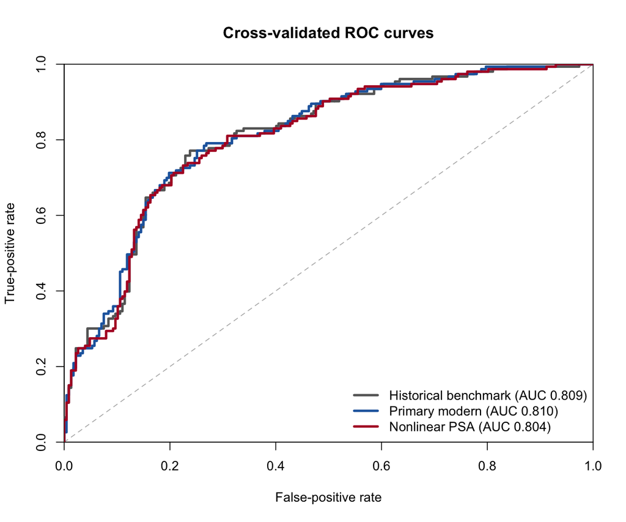

Figure 1: Cross-validated ROC curves

The cross-validated ROC curves in Figure 1 demonstrate the close discrimination of the historical and primary modern models and the slightly weaker discrimination of the nonlinear model.

## 5.3 Calibration and overfitting

Mean calibration intercepts were close to zero for all three models:

- −0.002 for the historical benchmark;
- −0.003 for the primary modern model; and
- −0.003 for the nonlinear PSA model.

These values indicate little average tendency to systematically overpredict or underpredict the overall frequency of capsule penetration.

Mean calibration slopes were below one:

- 0.920 for the historical benchmark;
- 0.914 for the primary modern model; and
- 0.884 for the nonlinear PSA model.

Slopes below one indicate that the predicted probabilities were somewhat too extreme when applied to held-out observations, consistent with modest overfitting. The lower slope of the nonlinear PSA model indicates greater overfitting associated with its additional flexibility.

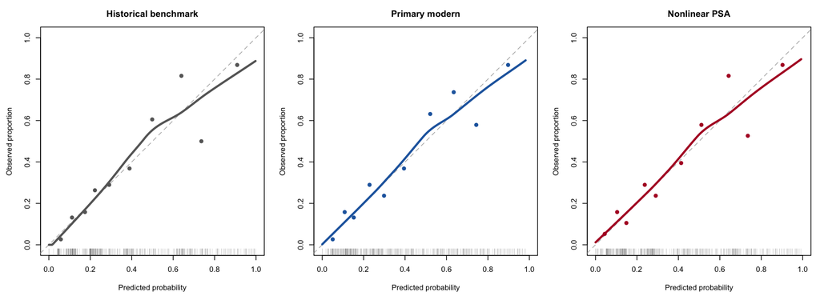

Figure 2: Cross-validated calibration curves

The calibration curves in Figure 2 show generally reasonable agreement between predicted and observed probabilities. Local departures are visible in parts of the predicted-risk range, but these should be interpreted cautiously because some regions contain relatively few observations.

## 5.4 Model stability

Repeat-level performance varied modestly according to how the observations were assigned to folds. The historical benchmark and primary modern model remained closely matched across the repeated partitions, whereas the nonlinear PSA model generally showed poorer probabilistic performance and calibration.

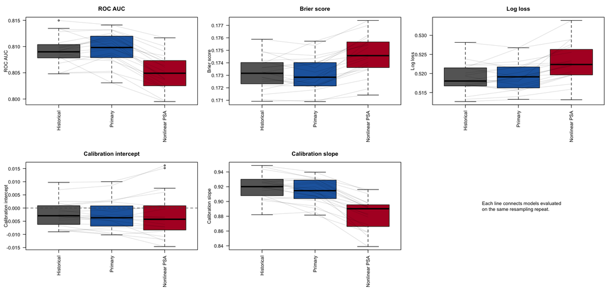

Figure 3: Paired performance across resampling repeats

The paired comparisons in Figure 3 demonstrate that the small differences between the historical and primary models were not uniformly in favor of either model across all performance measures and repeats.

Individual predicted probabilities also varied across resampling partitions. For each observation, the standard deviation of its 20 out-of-fold predictions was calculated and then averaged across observations.

Table 6: Variability of individual out-of-fold predictions across repeats

| Model | Mean within-observation prediction SD |
| --- | --- |
| Historical benchmark | 0.0160 |
| Primary modern | 0.0173 |
| Nonlinear PSA | 0.0197 |

The nonlinear model produced the greatest prediction variability. This pattern, together with its poorer calibration slope and prediction-error measures, indicates that its additional flexibility increased instability without improving predictive performance.

The variability also illustrates an important limitation of individual predictions from a relatively small dataset: two models fitted to slightly different subsets of the same population can assign meaningfully different probabilities to the same patient.

## 5.5 Primary-model coefficients

After internal validation was completed, the primary modern model was fitted to all 380 observations. Its coefficient estimates are summarized in Table 7.

Table 7: Full-data coefficient estimates for the primary modern model

| Predictor | Coefficient | Odds ratio | 95% Wald odds-ratio interval |
| --- | --- | --- | --- |
| Age, per year | −0.012 | 0.99 | 0.95 to 1.03 |
| `dpros = 2` versus 1 | 0.768 | 2.15 | 1.07 to 4.33 |
| `dpros = 3` versus 1 | 1.527 | 4.60 | 2.22 to 9.56 |
| `dpros = 4` versus 1 | 1.484 | 4.41 | 1.85 to 10.52 |
| PSA, per doubling | 0.349 | 1.42 | 1.15 to 1.75 |
| Gleason score, per point | 0.962 | 2.62 | 1.89 to 3.62 |

Holding the remaining predictors constant, higher digital rectal examination categories were associated with greater odds of capsule penetration relative to category 1. Each doubling of PSA was associated with approximately 42% higher odds of capsule penetration, and each one-point increase in Gleason score was associated with approximately 2.62 times the odds.

Age contributed little additional information after accounting for `dpros`, PSA, and Gleason score.

These estimates describe conditional associations within the complete historical dataset. They do not establish causal effects. The model’s apparent performance when fitted to all observations is also not an estimate of out-of-sample accuracy; the cross-validated results remain primary.

## 5.6 Sensitivity and exploratory results

The principal findings from the prespecified sensitivity and exploratory analyses are summarized in Table 8.

Table 8: Summary of sensitivity and exploratory analyses

| Analysis | Main performance finding | Calibration finding | Conclusion |
| --- | --- | --- | --- |
| Add `dcaps` | Negligible and inconsistent changes | Calibration slope decreased by approximately 0.011 | No meaningful incremental predictive value |
| Exclude zero-Gleason records | Matched performance was effectively unchanged | Intercept and slope were effectively unchanged | Primary conclusions were robust |
| Add two-part tumor volume | Small improvements in AUC and prediction error | Calibration slope decreased by approximately 0.021 | Inconclusive and exploratory |

### 5.6.1 Addition of `dcaps`

Adding `dcaps` to the primary model increased mean AUC by approximately 0.00017 and reduced the Brier score by approximately 0.00018. However, log loss increased by approximately 0.00059, and the calibration slope moved approximately 0.011 farther from one.

The changes were extremely small and did not consistently favor the extended model. The full-data coefficient for `dcaps` was also imprecisely estimated. The analysis therefore found no meaningful or stable incremental predictive value from adding `dcaps` beyond age, `dpros`, PSA, and Gleason score.

### 5.6.2 Exclusion of zero-Gleason records

Records 282 and 357, both of which had `capsule = 0`, were excluded in the prespecified data-quality sensitivity analysis. The reduced analysis population contained 378 observations and 153 capsule-penetration outcomes.

For the matched comparison on the same 378 observations, AUC rankings were unchanged, the mean Brier-score difference was less than 0.000001, and the mean log-loss difference was less than 0.000002. Calibration and full-data coefficients were also effectively unchanged.

The two zero Gleason scores therefore did not materially affect the analysis. Retaining them in the primary model, in accordance with the documented public data, is supported by this result.

### 5.6.3 Exploratory tumor-volume model

The exploratory model added an indicator distinguishing zero from positive recorded tumor volume and a `log2(vol)` term among observations with positive volume.

Relative to the primary model, it increased mean AUC by approximately 0.0032, reduced the Brier score by approximately 0.0011, and reduced log loss by approximately 0.0007. These small improvements were not uniform across repeats and were accompanied by a calibration slope approximately 0.021 farther from one.

In the full-data exploratory model, the coefficient distinguishing zero from positive volume was imprecise, the coefficient for changes among positive volumes was effectively zero, and the fitted relationship was nearly flat across the positive-volume range. Any apparent predictive information may therefore arise primarily from the distinction between zero and positive recorded volume rather than from increasing tumor volume.

Because the meaning of the 167 zero values is uncertain, this distinction cannot be interpreted confidently. The tumor-volume result is therefore classified as inconclusive and exploratory and does not justify adding volume to the primary model. The fitted exploratory relationship is shown in Figure 4 in the supplementary material.

Overall, the sensitivity analyses supported the primary conclusions. Neither `dcaps` nor the unusual zero Gleason records materially changed the findings, and the small exploratory improvements from tumor volume were offset by worse calibration and uncertainty about its historical coding.

# 6 Discussion

## 6.1 Principal findings

This project reproduced the central results of the 2018 SDSU analysis and extended that work by evaluating out-of-sample predictive performance. The historical benchmark achieved a mean cross-validated ROC AUC of approximately 0.81, indicating useful but imperfect discrimination between patients with and without prostatic capsule penetration.

The prespecified primary modern model performed almost identically to the historical benchmark. Adding age and representing PSA as `log2(psa)` improved interpretation but did not materially improve prediction. The small differences in AUC, Brier score, log loss, and calibration varied in direction and were not large enough to establish the superiority of either model.

Allowing a nonlinear PSA relationship did not improve predictive performance. The nonlinear model had slightly poorer discrimination and prediction error, a lower calibration slope, and greater variability in individual predicted probabilities. Its additional flexibility therefore increased instability without yielding a predictive benefit.

All three models had calibration intercepts close to zero, indicating little systematic overprediction or underprediction of the overall outcome frequency. Their calibration slopes were below one, however, suggesting that predicted probabilities were somewhat too extreme in held-out observations. This evidence of modest overfitting was greatest for the nonlinear model.

Taken together, the results favor a parsimonious logistic regression model. More complex representations and additional predictors did not produce a clear, stable improvement in this dataset.

## 6.2 Relationship to the 2018 conclusions

The reproduction confirmed most of the central numerical findings reported in 2018. PSA, Gleason score, and digital rectal examination findings were associated with capsule penetration, and the reported final-model coefficients, confidence intervals, odds ratios, and AIC were recovered.

The modern analysis also confirmed that these predictors contain useful predictive information. This extends the historical findings beyond in-sample association: the model retained meaningful discrimination when predictions were generated for observations excluded from model fitting.

Two aspects of the historical analysis required qualification. The p-value reported as 0.31 for `dpros = 2` was reproduced as 0.02997 and was classified as a typographical error. In addition, the model selected by the documented stepwise AIC procedure contained a `dpros`-by-PSA interaction and differed from the final model reported in 2018. The available materials did not explain the transition between these models.

These findings do not invalidate the reported final model, which was numerically reproducible. They clarify that it was not the direct output of the documented stepwise procedure.

The modern extension also changes the interpretation of model adequacy. The 2018 analysis showed that several baseline measurements were associated with capsule penetration within the analyzed sample. The present analysis demonstrates that the same measurements support moderately accurate internal predictions, while also revealing modest overfitting and variability that could not be identified from the historical in-sample results alone.

## 6.3 Parsimony and model complexity

The similarity between the historical benchmark and primary modern model is substantively important. The addition of age and transformation of PSA altered model specification but produced almost no change in cross-validated performance. The historical benchmark therefore remains a competitive and somewhat simpler predictive model within this dataset.

The nonlinear PSA model required two additional predictor parameters relative to the primary model. The formal sample-size assessment indicated that this level of complexity was not supported under the most conservative anticipated-performance scenario. Its empirical performance was consistent with that concern: it had worse calibration, slightly worse prediction error, and more variable individual predictions.

This result illustrates why additional flexibility should not be assumed to improve prediction. A more flexible model can describe patterns in its training observations that do not persist in held-out data. With only 380 observations, small changes in the model-development sample can also alter estimated nonlinear relationships and individual risk predictions.

The analysis therefore supports retaining the primary model in its prespecified role while recognizing that it did not outperform the simpler benchmark. It does not support adopting the nonlinear model.

Parsimony is especially important because the available validation is internal. A model that performs marginally better in repeated cross-validation but requires more parameters may not retain that advantage in a different population. In the present analysis, even that marginal improvement was absent.

## 6.4 Interpretation of PSA

The historical benchmark modeled PSA in its original units. Its coefficient described the change in odds associated with a one-unit increase in PSA, regardless of the starting value. Because PSA was strongly right-skewed and ranged from 0.3 to 139.7, this representation may not reflect how proportional changes are interpreted across its observed range.

The primary modern model used `log2(psa)`. Under this representation, a one-unit increase corresponds to a doubling of PSA. The fitted full-data coefficient indicated that each doubling was associated with approximately 42% higher odds of capsule penetration, conditional on the other predictors.

The logarithmic transformation therefore offered a clearer proportional interpretation. It also reduced the influence of very large PSA values. Its use was supported primarily by interpretability and distributional considerations, not by a demonstrated improvement in predictive performance.

The nonlinear model examined whether the relationship between log-transformed PSA and capsule penetration required additional curvature. Its poorer cross-validated performance provided no evidence that the added spline flexibility was beneficial. Within the limits of this dataset, a linear term for `log2(psa)` was adequate for the modern model.

This conclusion should not be interpreted as proof that the underlying biological relationship is exactly linear on the log-odds scale. It indicates only that the available sample did not support the prespecified nonlinear extension as a better predictive representation.

## 6.5 Sensitivity findings

Adding baseline detection of capsular involvement (`dcaps`) produced negligible and inconsistent changes in predictive performance. Its addition did not meaningfully improve discrimination, overall prediction error, or calibration. Excluding it from the primary model therefore does not appear to omit an important source of incremental predictive information.

Removing the two observations with Gleason score equal to zero had virtually no effect on matched cross-validated performance, calibration, or full-data coefficients. The primary conclusions were not driven by these unusual records, supporting the decision to retain them as documented in the public dataset.

The exploratory tumor-volume model produced small improvements in AUC, Brier score, and log loss, but these improvements were not uniform across resampling repeats and were accompanied by a worse calibration slope. The fitted relationship among positive volume values was nearly flat, suggesting that any apparent information arose mainly from distinguishing zero from positive recorded volume.

Because the meaning of the 167 zero volume values is unknown, this distinction cannot be interpreted reliably. The volume results are therefore inconclusive and do not justify adding tumor volume to the primary model.

Collectively, the sensitivity analyses reinforce the main conclusion: none of the examined additions or exclusions produced a clear and stable improvement over the prespecified primary model.

## 6.6 Implications

The project demonstrates how an earlier statistical analysis can be extended without erasing its historical context. Reproducing the original workflow first made it possible to distinguish numerical agreement, typographical error, undocumented analytical judgment, and methodological limitations.

Prespecification was important because it separated planned comparisons from conclusions formed after examining the results. The primary model retained its designated role even though it did not achieve uniformly better performance than the historical benchmark. Similarly, the tumor-volume model remained exploratory despite small improvements in several measures.

Repeated cross-validation provided information that apparent full-data performance could not. It showed that discrimination remained useful in held-out observations, while calibration slopes and prediction variability revealed modest overfitting and uncertainty in individual probabilities.

The findings also illustrate that modernizing an analysis does not necessarily mean adopting a more complicated model. In this project, the most useful improvements were reproducible data acquisition, explicit predictor definitions, prespecification, leakage controls, internal validation, calibration assessment, and transparent sensitivity analyses. Increasing model complexity itself did not improve the findings.

For this historical dataset, a straightforward logistic regression using digital rectal examination findings, PSA, and Gleason score provides a reasonable baseline. However, the available evidence is insufficient to select a model for contemporary clinical use.

# 7 Limitations

This project has several important limitations.

First, the dataset contains only 380 observations and 153 capsule-penetration outcomes. Although the formal assessment supported the primary model for this educational internal-validation study, the margin was narrow under conservative assumptions. Coefficient estimates, calibration, and individual predicted probabilities may therefore remain unstable. The more complex nonlinear, `dcaps`, and tumor-volume models were less well supported.

Second, the data originated from a single historical clinical setting. Clinical practices, diagnostic definitions, patient characteristics, PSA measurement, imaging, biopsy procedures, Gleason grading, and treatment pathways may differ from contemporary practice. Performance in this dataset cannot establish transportability to current patients or other institutions.

Third, the published values were modified to protect confidentiality. Although the dataset retains value for statistical education, its measurements should not be interpreted as an unaltered contemporary clinical cohort.

Fourth, the demographic information is limited. Race was represented using only two historical codes, had three missing values, and included relatively few observations in the second category. Race was therefore excluded from modern prediction. The dataset cannot support a meaningful assessment of algorithmic fairness or performance across relevant demographic and clinical subgroups.

Fifth, the meaning of the 167 zero tumor-volume values is uncertain. They may indicate no measurable tumor, a measurement below detection, an examination not performed, missing information encoded as zero, or another historical convention. This uncertainty prevents confident interpretation of the exploratory distinction between zero and positive volume.

Sixth, two observations had Gleason scores recorded as zero. The prespecified exclusion analysis showed that they did not materially affect the results, but their presence illustrates the limited contextual documentation available for unusual historical values.

Seventh, the analysis used repeated cross-validation for internal validation but had no independent external-validation dataset. Repeated cross-validation uses the available sample efficiently and exposes sensitivity to different partitions, but it does not create new independent observations. Estimates from the 20 repeats are correlated, and their percentile ranges describe resampling variability rather than formal confidence intervals.

Eighth, individual out-of-fold probabilities varied across resampling repeats. This instability was greatest for the nonlinear model but was also present for the simpler models. Consequently, the reported average performance should not be interpreted as evidence that every individual prediction is precise or reliable.

Ninth, the project deliberately evaluated a limited model set. It did not conduct an unrestricted comparison of machine-learning algorithms, interactions, transformations, spline specifications, or penalized models. This restriction reduced data-driven selection and overfitting but means that unexamined approaches could perform differently. The current sample would not support a broad model search with reliable internal comparison.

Tenth, the project did not define a clinical intervention or a defensible probability threshold. Threshold-dependent classification performance, decision-curve analysis, clinical consequences, and effects on patient outcomes were therefore not evaluated.

Finally, no model was externally validated, prospectively evaluated, or compared with contemporary clinical practice. The results establish reproducibility and internally validated predictive performance only within this historical teaching dataset. They do not establish contemporary clinical validity, fairness, utility, or safety, and the models must not be used for clinical decision-making.

# 8 Reproducibility and Transparency

The project was organized as a sequence of documented and independently reviewable stages. Historical reproduction was separated from modern model development so that the 2018 analysis could be assessed on its own terms before methodological extensions were introduced.

The modern analysis plan, predictor specifications, candidate models, validation procedure, performance measures, and sensitivity analyses were documented before the modern models were fitted and compared. A formal sample-size and model-complexity assessment was also completed before model fitting.

The analysis followed the approved protocol. No stepwise selection, univariate predictor screening, class balancing, unrestricted algorithm comparison, or post hoc search for additional models was performed. The primary modern model retained its prespecified status even though it did not materially outperform the historical benchmark. The `dcaps` analysis remained a sensitivity analysis, and the tumor-volume analysis remained exploratory after their results were examined.

## 8.1 Reproducible workflow

The principal workflow stages are summarized in Table 9.

Table 9: Reproducibility map from analysis stages to scripts and outputs

| Stage | Script | Principal inputs | Principal outputs and controls |
| --- | --- | --- | --- |
| Public data acquisition | `R/01_acquire_data.R` | `lbreg::PCS` | Verifies source dimensions, variables, identifiers, outcome counts, and missingness; creates the historical and modern processed datasets and records MD5 checksums |
| Historical reproduction | `R/02_reproduce_2018.R` | `data/processed/prostate_2018.rds` | Produces descriptive, univariate, model-selection, final-model, and diagnostic results under `results/historical/` and figures under `figures/historical/` |
| Modern input validation | `R/03_validate_inputs.R` | `data/processed/prostate_modern.rds` and acquisition metadata | Performs 25 integrity, structure, coding, range, missingness, transformation, and model-readiness checks; stops if a required check fails |
| Primary modern analysis | `R/04_modern_analysis.R` | Validated modern data | Creates and saves stratified repeated cross-validation assignments, out-of-fold predictions, performance summaries, full-data model results, diagnostics, and primary figures |
| Sensitivity and exploratory analyses | `R/05_sensitivity_analyses.R` | Validated modern data and saved resampling assignments | Reuses the primary folds for the `dcaps`, zero-Gleason, and tumor-volume analyses; saves paired comparisons, predictions, diagnostics, summaries, and the exploratory volume figure |

The scripts are intended to be run from the project root in numerical order. Each script checks for required project files and expected inputs before performing its analysis. The workflow stops when expected dataset properties, files, transformations, resampling assignments, or output conditions are not satisfied.

Generated processed datasets are excluded from version control because they can be recreated from the documented public source. The acquisition script records the source package version, R version, transformations, dataset dimensions, outcome counts, missing-value locations, and MD5 checksums of the generated files.

The modern input-validation script compares the processed dataset with its recorded checksum and verifies the planned transformations before model fitting. All 25 checks passed for the analysis reported here.

## 8.2 Computational environment and resampling

Package versions are recorded in `renv.lock`. The project environment can be restored with:

```r
renv::restore()
```

The modern analysis used the fixed random seed `20260803`. All 7,600 cross-validation assignments were saved, and identical folds were used for every primary model comparison. The sensitivity and exploratory analyses reused those assignments rather than generating new partitions.

All data-dependent modeling operations were performed within the corresponding cross-validation analysis fold. In particular, the natural-spline basis was constructed without using held-out assessment observations. No outcome information from an assessment fold was used to fit the model generating that fold’s predictions.

Machine-readable out-of-fold predictions, repeat-level performance estimates, paired model comparisons, coefficients, diagnostics, and analysis metadata are retained under `results/`. Figures are produced programmatically and stored under `figures/`.

The scripts record convergence and prediction checks for every fitted cross-validation model. All models converged, all expected predictions were generated, and all probabilities were finite and strictly between zero and one.

## 8.3 Documentation and provenance

The repository preserves separate documents for:

- the historical reproduction protocol;
- the historical reproduction findings;
- the modern analysis plan;
- the formal sample-size and model-complexity assessment; and
- the modern analysis findings.

These documents provide technical detail without requiring the integrated report to duplicate every calculation or implementation decision.

The original 2018 report is treated as a historical source and is not silently revised. Corrections and ambiguities identified by the reproduction are documented in the new materials instead.

Git records the development history of the project, including the addition and review of the data policy, analysis plans, scripts, results, findings, and integrated report. This staged history distinguishes decisions made before analysis from interpretations made after results were available.

Together, the public data source, recorded package environment, validation checks, fixed seed, saved resampling assignments, scripted outputs, and version history provide an auditable path from source data to reported conclusions.

# 9 Conclusions

The principal numerical results of the 2018 SDSU analysis were highly reproducible. Dataset counts, descriptive results, principal univariate findings, final-model coefficients, confidence intervals, odds ratios, and the reported AIC were recovered from the verified historical data.

The reproduction identified two qualifications. The p-value reported as 0.31 for `dpros = 2` was reproduced as 0.02997 and is best understood as a typographical error. The documented stepwise AIC procedure also selected a model different from the final model reported in 2018, and the reason for that transition could not be determined from the available materials.

The modern extension found that baseline digital rectal examination findings, PSA, and Gleason score provided useful but imperfect prediction of prostatic capsule penetration. The historical benchmark achieved a mean internally validated ROC AUC of approximately 0.81.

The prespecified primary modern model performed almost identically to the historical benchmark. Representing PSA as `log2(psa)` provided a clearer interpretation in terms of PSA doubling, but adding age and changing the PSA representation did not materially improve predictive performance.

The nonlinear PSA model added complexity and prediction instability without improving discrimination, calibration, or overall prediction error. Calibration slopes below one for all primary comparison models indicated modest overfitting, with the greatest overfitting in the nonlinear model.

Adding `dcaps` did not provide meaningful incremental predictive value, and excluding the two zero Gleason scores did not change the conclusions. Tumor volume produced small exploratory improvements in some measures but worse calibration, a nearly flat relationship among positive values, and unresolved uncertainty about the meaning of its numerous zero values. It should not be added to the primary model on the basis of these results.

The overall findings favor parsimony. Within this dataset, a straightforward logistic regression model performed as well as the examined extensions, while additional flexibility did not produce a clear and stable benefit.

The project also shows that the most meaningful modernization of a historical analysis may lie in its scientific process rather than its model complexity. Public data acquisition, prespecification, formal complexity assessment, leakage controls, repeated internal validation, calibration assessment, sensitivity analysis, and transparent reporting strengthened the evidence without requiring a more elaborate algorithm.

These conclusions apply only to this small, confidentiality-modified dataset from a single historical clinical setting. No model has been externally or prospectively validated, and clinical utility was not evaluated. The models should therefore be regarded as educational demonstrations of reproducible prediction analysis, not as contemporary clinical prediction tools.

# References

Collins, G. S., Moons, K. G. M., Dhiman, P., et al. (2024). TRIPOD+AI statement: Updated guidance for reporting clinical prediction models that use regression or machine learning methods. *BMJ, 385*, e078378. https://doi.org/10.1136/bmj-2023-078378

Hedayati, N. (2018). *Detection of Prostate Cancer: Data Analysis Report 2*. Unpublished course report, STAT 696: Statistical Communication in Data Science, San Diego State University.

Hosmer, D. W., Jr., & Lemeshow, S. (2000). *Applied Logistic Regression* (2nd ed.). John Wiley & Sons. https://doi.org/10.1002/0471722146

Moons, K. G. M., Damen, J. A. A., Kaul, T., et al. (2025). PROBAST+AI: An updated quality, risk of bias, and applicability assessment tool for prediction models using regression or artificial intelligence methods. *BMJ, 388*, e082505. https://doi.org/10.1136/bmj-2024-082505

Riley, R. D., Snell, K. I. E., Ensor, J., et al. (2019). Minimum sample size for developing a multivariable prediction model: Part II—Binary and time-to-event outcomes. *Statistics in Medicine, 38*, 1276–1296. https://doi.org/10.1002/sim.7992

# Supplementary Material

The supplementary materials provide technical detail and machine-readable results supporting the integrated report. They are retained separately to avoid duplicating the main narrative.

## 9.1 Technical documentation

The analytical decisions, implementation specifications, and detailed findings are documented in:

- Historical reproduction plan
- Historical reproduction findings
- Modern analysis plan
- Sample-size and model-complexity assessment
- Modern analysis findings

## 9.2 Machine-readable results

Historical reproduction outputs are stored under `results/historical/`. These include dataset counts, descriptive statistics, univariate tests, model-selection results, final-model estimates, diagnostic summaries, and reported-versus-reproduced comparisons.

Modern analysis outputs are stored under `results/modern/`. Principal files include:

- `performance_summary.csv`: cross-validated performance summaries for the three primary comparison models;
- `resampling_performance.csv`: performance estimates for every model and resampling repeat;
- `paired_metric_differences.csv`: paired repeat-level comparisons between primary models;
- `out_of_fold_predictions.csv`: observation-level out-of-fold predictions;
- `mean_out_of_fold_predictions.csv`: prediction means and variability across repeats;
- `full_model_coefficients.csv`: full-data coefficient estimates;
- `resampling_assignments.csv`: the saved cross-validation folds;
- `resampling_diagnostics.csv`: convergence and prediction checks;
- `sensitivity_performance_summary.csv`: performance summaries for sensitivity and exploratory models;
- `sensitivity_paired_differences.csv`: paired comparisons with the applicable primary-model reference; and
- `sensitivity_full_model_coefficients.csv`: coefficients from the full-data sensitivity and exploratory models.

The percentile ranges in these files describe variability across correlated cross-validation repeats. They are not formal confidence intervals.

## 9.3 Figures

Historical figures are stored under `figures/historical/`, and modern prediction figures are stored under `figures/modern/`. All figures were produced programmatically by the analysis scripts.

The main report presents the cross-validated ROC, calibration, and paired-performance figures. Additional files include predicted-probability distributions and sensitivity-analysis comparisons.

## 9.4 Exploratory tumor-volume figure

Figure 4 shows the apparent full-data relationship between recorded tumor volume and predicted capsule-penetration probability from the exploratory two-part volume model.

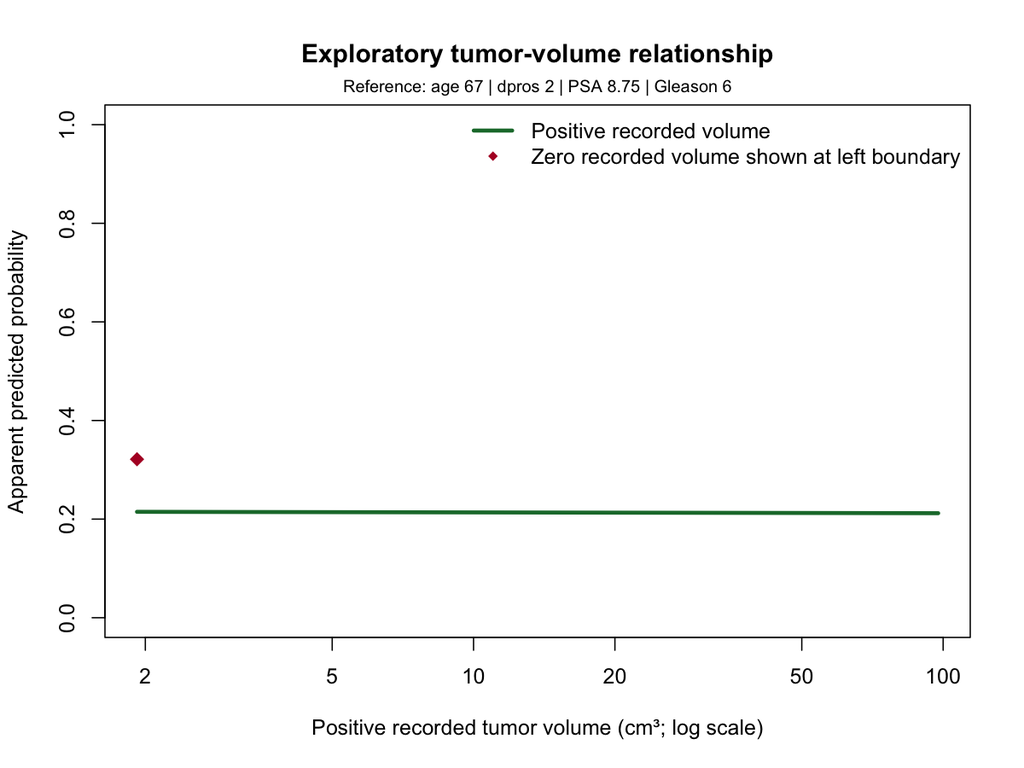

Figure 4: Exploratory tumor-volume relationship

The plotted probabilities hold age, `dpros`, PSA, and Gleason score at fixed reference values. The figure is descriptive and exploratory. It does not represent externally validated performance or establish a causal relationship between tumor volume and capsule penetration.

The relationship among positive recorded volumes is nearly flat. Interpretation remains limited by uncertainty about what the 167 recorded zero values represent.